# Challenge 4

- Show All Code
- Hide All Code
- View Source

Author

Eva Dykaar

For the housing price data set, I made it myself combining information from zillow. All links are below: https://www.zillow.com/home-values/20330/san-francisco-ca/ https://www.zillow.com/home-values/20330/los-angeles/ https://www.zillow.com/home-values/20330/san-diego/ https://www.zillow.com/home-values/20330/sacramento/

```r
# loading in packages and importing data
#| message: false

library(tidyverse)
library(here)
library(ggplot2)
library(ggridges)
avocado <- read_csv(here("Week 4", "avocado.csv"))
house_price <- read_csv(here("Week 4", "housing price.csv"))
```

### Set Up for Challenge

```r
# cleaning the data: Renaming columns
# source for avocado size code: https://loveonetoday.com/how-to/identify-hass-avocados/

avocado <- avocado |>
  rename("Small/medium" = "4046") |>
  rename("Large" = "4225") |>
  rename("Xlarge" = "4770")
```

```r
# Cleaning the data: Region column

total <- tibble(region = "TotalUS")

regions <- tibble(region = c("West",
                             "GreatLakes",
                             "Midsouth",
                             "Northeast",
                             "SouthCentral",
                             "Southeast",
                             "WestTexNewMexico"))

states <- tibble(region = c("California",
                            "NorthernNewEngland",
                            "SouthCarolina",
                            "NewYork"))

avocado_regions <- avocado |>
  semi_join(regions, by = "region")

avocado_states <- avocado |>
  semi_join(states, by = "region")

avocado_clean <- avocado |>
  anti_join(regions, by = "region") |>
  anti_join(states, by = "region") |>
  anti_join(total, by = "region")
```

```r
avocado_ca2 <- avocado_clean |>
  filter(region %in% c("LosAngeles",
                    "SanDiego",
                    "Sacramento",
                    "SanFrancisco")) |>
  full_join(house_price, by = c("region", "year"))
```

Now that I have joined my two data sets together I am going to make the assumption that the average person in California eats 1 avocado per time they make avocado toast and that they have one avocado toast a day, everyday each week, so 365 avocados a year. I am just going to be using the cost of the avocado, and not the cost of the bread or any other cost.

```r
# calculating the average price of an avocado per year and city and adding a column

avocado_ca2 <- avocado_ca2 |>
  group_by(year, region, price) |>
  mutate(avg_price_yr = mean(AveragePrice))
```

```r
# calculating the amount a person spends on avocados a year if they buy 365 avocados a year

avocado_ca2 <- avocado_ca2 |>
  mutate(dollars_avo_yr = avg_price_yr * 365)
```

```r
# Calculating how many years it would take to buy a house if one did not buy avocados and saved up that money to buy a house

avocado_ca2 <- avocado_ca2 |>
  mutate(years = price / dollars_avo_yr)
```

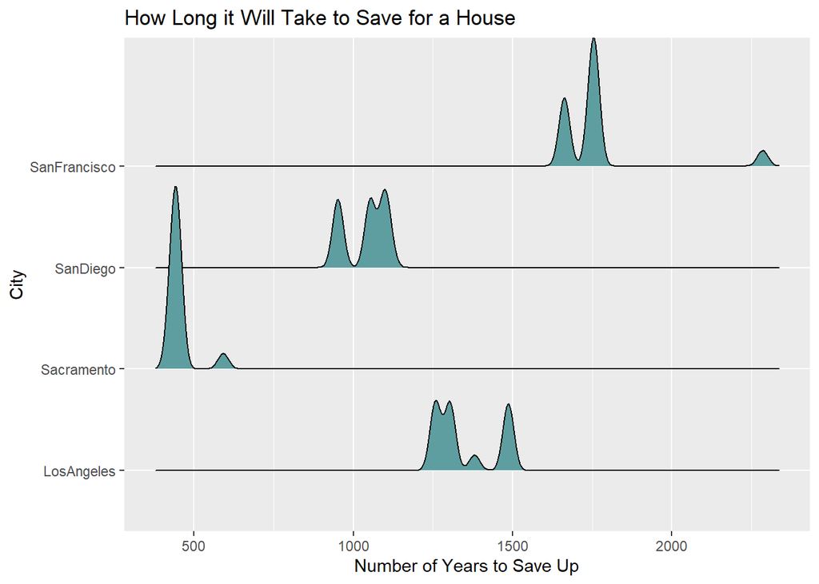

```r
# Plotting the data

ggplot(data = avocado_ca2, mapping = aes(x = years, y = region)) +
   geom_density_ridges(fill = "cadetblue") +
   labs(x = "Number of Years to Save Up",
        y = "City",
        title = "How Long it Will Take to Save for a House")
```

In this graph it shows density plots for how many years it would take to save the amount of money spent on avocado toast to be able to buy a house based on the city one lives in. To buy a house in Sacramento (the lowest of the 4 cities) would take on average a little less then 500 years which would be equivalent to at least 5 lifetimes if one saved on avocado toast. It is safe to say avocado toast is not the reason that millennial’s are not able to buy houses.